# Boite à outils R

2021-09-02

# Environnement de travail

## Conflits de package DPLYR

```r
library(tidyverse)  # pour ggplot, dplyr
conflict_prefer("filter", "dplyr")
conflict_prefer("select", "dplyr")
```

## Créer un dossier

```r
library(here)
dir.create("data_output")
```

## Enregistrer les variables

```r
save.image("nom")
load("nom")
```

## Importations

### Import csv ou excel

```r
# csv
data <- read.csv(file="data/fichier.csv", dec = ".", sep = ";", h=T, stringsAsFactors = F)

# excel
library(readxl)
data <- read_excel("fichier.xlsx") # intégration du fichier excel
excel_sheets("data/fichier.xlsx") # visualisation des différents onglets
data <- read_excel("data/fichier.xlsx", sheet = "nom_onglet") # enregistrement de l'onglet en dataframe
data <- as_tibble(data) # transformation format tibble (optimisé pour dplyr)
```

### Importations multiples de fichiers csv

```r
files_list <- list.files(here::here("data"),pattern = "*.csv")
library(stringr)
data_names <- str_remove(files_list, ".csv")

for(i in 1: length(files_list)) {
  x <- read.csv2(here::here("data",files_list[i]))
  assign(data_names[i], x)
    }
rm(x)
```

### Importer et assembler multiples csv

```r
library(dplyr)
library(purrr)
mario_data <- list.files(path = "data2", full.names = TRUE) %>%
    set_names() %>%
    map_dfr(~ read.csv2(.x),.id="file_name") %>%
    mutate(file_name=str_remove(file_name, "data2/")) %>%
    mutate(file_name=str_remove(file_name, ".csv"))
```

## Exportations

### Export csv

```r
write.csv2(table_finale, file = "data_output/nom_du_fichier.csv", row.names = FALSE) # decimal(,) et sep(;)

write.table(table_finale, "data/nom_du_fichier.csv", row.names = FALSE, sep =";",dec = ",", na =" ")
```

# Préparation des données

## Structure et format

### Voir la structure des données

```r
str(data)

library(skimr)
skim(data)
```

### Doublons

```r
# Fonction pour vérifier les doublons
duplicated2 <- function(x) {
    if (sum(dup <- duplicated(x)) == 0)
        return(dup)
    if (class(x) %in% c("data.frame", "matrix"))
        duplicated(rbind(x[dup, ], x))[-(1:sum(dup))] else duplicated(c(x[dup], x))[-(1:sum(dup))]
}

table(duplicated2(HC_2017$Employee_ID))

HC_2018[which(duplicated(HC_2018$Employee_ID) == TRUE), "Employee_ID"]  # récupération du matricule en double
HC_2018 %>%
    filter(Employee_ID == "W00054434")  # visualisation des lignes => erreur Erin Leslie
HC_2018 <- HC_2018[!duplicated(HC_2018$Employee_ID), ]  # pour enlever la 2ème ligne Erin
```

### Changer une valeur

```r
data[data$COLONNE == "VALEUR_COLONNE", "COLONNE_A_MODIFIER"] <- "NEW_VALEUR"
```

### Transformer en numeric

```r
data %>%
    select(COL1:COL3) %>%
    mutate_at(vars(), ~(.as.numeric))
```

### Transformer en date

```r
data$DATENAISSANCE = as.Date(data$DATENAISSANCE)

data$AGE = difftime(Sys.Date(), data$DATENAISSANCE, units = "days")/365.25  # calculer un âge
data$AGE = round(as.numeric(data$AGE))

library(lubridate)
data$COLONNE_date <- dmy(data$COLONNE_date)
```

### Transformer en factor (+levels)

```r
LEBI_HC$Is_Manager <- factor(LEBI_HC$Is_Manager, levels = c("Yes", "No"))
```

### Casse des données

```r
data$COLONNE <- toupper(data$COLONNE)  # tout en majuscules
data$COLONNE <- tolower(data$COLONNE)  # tout en minuscules
data$COLONNE <- str_to_title(data$COLONNE)  # 1ère lettre en majuscule
```

### Rownames en Colnames

```r
mtcars %>%
    tibble::rownames_to_column("car_model") %>%
    head
```

### Transformer en Rownames

```r
row.names(data_ronfl) = data$ID
```

## Gestion des NA

### Nombre de NA

```r
sum(is.na(LEBI_HC_ALL))
```

### Remplacer NA par une valeur

```r
data[which(is.na(data$COLONNE)), "COLONNE"] <- 0

# Remplacer les NA de plusieurs colonnes (par 0)
data <- mutate_at(basis_Tableau, c("COLONNE1", "COLONNE2", "COLONNE3"), ~replace(.,
    is.na(.), 0))
```

### Afficher valeurs NA d’une colonne et 2 colonnes

```r
data[is.na(data$COLONNE), c("COLONNE", "AUTRE_COLONNE")]
```

### Affecter une valeur “manquant” en NA

```r
data %>%
    select(COL1:COLx) %>%
    na_if("manquant")
```

### Visualiser les NA

```r
library(naniar)
gg_miss_var(data)
```

## Sélectionner

### Certaines colonnes

```r
data %>%
    select(name, genus, sleep_total, awake) %>%
    glimpse()
```

### Toutes les colonnes sauf certaines

```r
library(dplyr)
data %>%
    select(-NOM_colonne, -NOM_colonne)
data %>%
    select(-conservation, -(sleep_total:awake)) %>%
    glimpse()
```

### Desélection puis ajout colonne

```r
data %>%
    select(-(name:awake), conservation) %>%
    glimpse()
```

### De la colonne x à la colonne y

```r
data %>%
    select(name:order, sleep_total:sleep_cycle) %>%
    glimpse()
```

### Avec une condition

```r
data %>%
    filter((AGE < 18 | AGE > 100))
```

### REGEX

```r
data %>%
    select(name, starts_with("sleep")) %>%
    glimpse()  # commence par

data %>%
    select(contains("eep"), ends_with("wt")) %>%
    glimpse()  # contient et se termine

data %>%
    select(matches("o.+er")) %>%
    glimpse()  # contient 'o' suivi de plusieures lettres et se terminant par 'er'
```

### En pré identifiant les colonnes

```r
classification <- c("name", "genus", "vore", "order", "conservation")
data %>%
    select(!!classification)
```

### Par data type

Pour dates, charger le package lubridate puis utiliser is.date ou is.POSIXT

```r
data %>%
    select_if(is.numeric) %>%
    glimpse()

data %>%
    select_if(~!is.numeric(.)) %>%
    glimpse()  # idem mais 'est différent'

data %>%
    select_if(is.numeric) %>%
    select_if(~mean(., na.rm = TRUE) > 10)  # est numeric et moyenne > 10
```

### Par nombre de valeurs distinctes

```r
data %>%
    select_if(~n_distinct(.) < 20)
```

## Supprimer

```r
data$COLONNE <- NULL  # supprimer une colonne

data <- data[-(1:15), ]  # supprimer x lignes
```

## Filtrer

```r
# Filtrer sur plusieurs critères d'une variables
variable <- c("FTC", "FTC CHINA", "TEMP", "UTC")
data <- data %>%
    filter(COLONNE %in% variable)
rm(variable)

# Not in
variable <- c("Claire PUJOS", "Estelle VERVAEKE", "Karen LINEHAN", "Nadine SPORTES")
data <- data %>%
    filter(!Employee %in% variable)
rm(variable)
```

## Renommer

```r
library(dplyr)
data %>% rename(NEW_name = OLD_name, NEW_name = OLD_name) %>% glimpse

data %>% select(NEW_name = OLD_name, COLONNE, NEW_name = OLD_name) %>%
  glimpse # les colonnes peuvent être directement renommées dans un select()


data$COLONNE  = gsub(",",".",data$COLONNE) # remplacer la virgule par un point

data <- data %>%
  select_all(~str_replace_all(., " ", "_")) # on remplace les espaces par un underscore


data %>% select_all(toupper) # nom des colonnes en majuscule

data %>%
  select_all(~str_replace(., "Q[0-9]+", "")) %>% # enlever des n° de question par ex
  select_all(~str_replace(., " ", "_")) # et remplacer un espace vide par un underscore
```

## Ordonner

```r
data %>%
    select(conservation, sleep_total, name) %>%
    glimpse()

data %>%
    select(conservation, sleep_total, everything()) %>%
    glimpse()  # certaines colonnes puis toutes les autres
```

## Créer

### Mutate (créer une colonne)

```r
data %>%
    select(name, sleep_total) %>%
    mutate(sleep_total_min = sleep_total * 60)


data %>%
    select(name, sleep_total) %>%
    mutate(sleep_total_vs_AVG = sleep_total - round(mean(sleep_total), 1), sleep_total_vs_MIN = sleep_total -
        min(sleep_total))

# Pour faire la somme ou la moyenne sur plusieurs colonnes il faut soit revenir
# à l'épellation de l'arithmétique : mutate(average = (sleep_rem + sleep_cycle)
# / 2) ou ajouter une **instruction spéciale au pipe** pour qu'il exécute ces
# fonctions d'agrégation non pas sur la colonne entière, mais par ligne :
data %>%
    select(name, contains("sleep")) %>%
    rowwise() %>%
    mutate(avg = mean(c(sleep_rem, sleep_cycle)))
```

### Mutate all (modifier toutes les modalités)

```r
# Mettre toutes les modalités en minuscule
data %>%
    mutate_all(tolower)

# Pour remplacer un caractère par un autre
data <- data %>%
    mutate_all(~str_replace_all(., "/n", "")) %>%
    mutate_all(str_trim)  # supprimer les espaces au début et à la fin
```

### Mutate if (spécifier une condition)

```r
data %>%
    select(name, sleep_total:bodywt) %>%
    mutate_if(is.numeric, round)
```

### Mutate at (changer des colonnes spécifiques)

```r
# Multiplier par 60 des colonnes qui contiennent 'sleep'
data %>%
    select(name, sleep_total:awake) %>%
    mutate_at(vars(contains("sleep")), ~(. * 60))

# Idem puis rajouter _min à la fin du nom des nouvelles variables
data %>%
    select(name, sleep_total:awake) %>%
    mutate_at(vars(contains("sleep")), ~(. * 60)) %>%
    rename_at(vars(contains("sleep")), ~paste0(., "_min"))
```

## Recoder valeurs

### Visualiser les différentes modalités

```r
table(data$COLONNE)
```

### Variables discrètes

```r
data %>%
  mutate(conservation2 = recode(conservation,
                                "en" = "Endangered",
                                "lc" = "Least_Concern",
                                "domesticated" = "Least_Concern",
                                .default = "other", # autres valeurs
                                .missing = "missing")) %>%
  count(conservation2)
```

### Variables discrètes à 2 niveaux

```r
data %>%
    select(name, sleep_total) %>%
    mutate(sleep_time = ifelse(sleep_total > 10, "long", "short"))
```

### Variables continues à 2 niveaux

```r
data <- heart_disease %>%
    mutate(has_heart_disease_num = ifelse(has_heart_disease == "no", 0, 1)) %>%
    mutate(has_heart_disease_num = as.numeric(has_heart_disease_num))
```

### Variables discrètes à plusieurs niveaux

```r
data %>% select(name, sleep_total) %>%
  mutate(sleep_total_discr = case_when(
    sleep_total > 13 ~ "very long",
    sleep_total > 10 ~ "long",
    sleep_total > 7 ~ "limited",
    TRUE ~ "short")) %>% # tous les autres
  mutate(sleep_total_discr = factor(sleep_total_discr,
                                    levels = c("short",
                                               "limited",
                                               "long",
                                               "very long")))



# Sur des colonnes différentes
data %>%
  mutate(silly_groups = case_when(
    brainwt < 0.001 ~ "light_headed",
    sleep_total > 10 ~ "lazy_sleeper",
    is.na(sleep_rem) ~ "absent_rem",
    TRUE ~ "other")) %>%
  count(silly_groups)
```

### Pour des facteurs

```r
data %>%
    mutate(conservation2 = recode_factor(conservation, en = "Endangered", lc = "Least_Concern",
        domesticated = "Least_Concern", .default = "other", .missing = "no data",
        .ordered = TRUE)) %>%
    count(conservation2)
```

### Récupérer le dernier mot d’une modalité

```r
library(stringr)
data %>%
    select(name) %>%
    mutate(name_last_word = tolower(str_extract(name, pattern = "\\w+$")))
```

## Join

```r
msleep %>%
    select(name, conservation) %>%
    mutate(conservation = toupper(conservation)) %>%
    left_join(conservation_table, by = c(conservation = "abbreviation")) %>%
    mutate(description = ifelse(is.na(description), conservation, description))
```

## Fractionner et fusionner

```r
# Séparation d'une colonne en 2 colonnes
conservation_table <- conservation_expl %>%
    separate(`conservation abbreviation`, into = c("abbreviation", "description"),
        sep = " = ")

# Regroupement de 2 colonnes en 1 colonne
conservation_table %>%
    unite(united_col, abbreviation, description, sep = ": ")

data1 <- data %>%
    select(name, contains("sleep")) %>%
    gather(key = "sleep_measure", value = "time", -name, factor_key = TRUE)

data1 %>%
    spread(sleep_measure, time)  # dégrouper
```

## Split en plusieurs lignes

```r
library(tidyr)
vaccination_final_vacc <- vaccination_final2 %>%
    separate_rows(VACCINES_USED, sep = ",")
```

## Format vertical

```r
library(reshape2)

# on récupère les noms des colonnes 'années' à transposer
var_annees <- colnames(basis_Tableau[grepl("^A_20", colnames(basis_Tableau))])

basis_Tableau_v <- melt(basis_Tableau, measure.vars = var_annees, variable.name = "Year",
    value.name = "Presence_Year")

# On réordonne les colonnes
basis_Tableau_v <- basis_Tableau_v %>%
    select(Employee_ID, Year, Presence_Year, everything())

# On remplace les NA par 0
basis_Tableau_v[which(is.na(basis_Tableau_v$Presence_Year)), "Presence_Year"] <- 0

basis_Tableau_v %>%
    group_by(Year) %>%
    summarise(sum(Presence_Year))
```

# Analyses descriptives

## Summarise

```r
HC <- LEBI_HC %>%
    summarise(HC_Number = length(Employee_ID), Avg_Age = round(mean(LEBI_HC$Age),
        2), Med_Age = round(median(LEBI_HC$Age), 2), Min_Age = round(min(LEBI_HC$Age),
        2), Max_Age = round(max(LEBI_HC$Age), 2), Sd_Age = round(sd(LEBI_HC$Age),
        2))


# Format horizontal
HC <- as_tibble(cbind(Statistics = names(HC), t(HC)))
```

# Plots

## Organisation des plots

*Plusieurs plots en un*

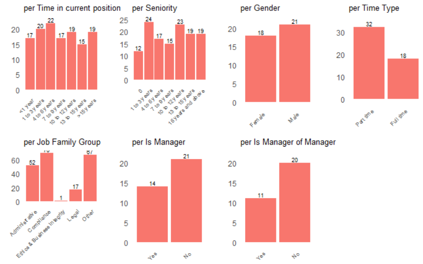

```r
# Avec p1, p2 etc les plots, sur 2 lignes et 4 colonnes
library(gridExtra)
grid.arrange(p1, p2, p3, p4, p5, p6, p7, nrow = 2, ncol = 4)
```

```r
# 2 plots l'un à côté de l'autre {r HFM_seniority, figures-side,
# fig.show='hold', out.width='50%', echo = FALSE}
par(mar = c(4, 4, 0.1, 0.1))
HFM_sen
HFM_sen_table
```

## Variables qualitatives

### Analyse univariée

*Frequency*

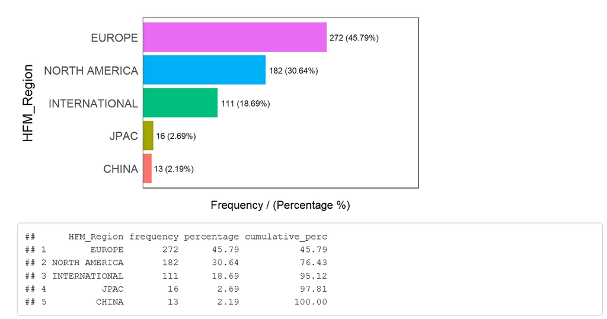

```r
library(funModeling)
freq(data, c("HFM_Region"))
```

*Barplot format vertical + nombre*

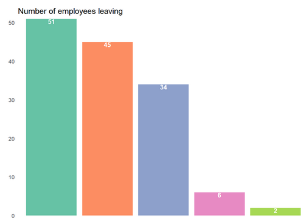

```r
termination$Job_Family_Group <- fct_infreq(termination$Job_Family_Group)  # changing order

par(mfrow = c(1, 2))
ggplot(termination) + aes(x = fct_infreq(Job_Family_Group), fill = Job_Family_Group) +
    geom_bar() + geom_text(aes(label = ..count..), stat = "count", position = position_dodge(0.5),
    vjust = "top", colour = "white", fontface = "bold", size = 3.5) + scale_x_discrete(labels = scales::label_wrap(10)) +
    scale_y_continuous(expand = c(0, 0)) + scale_fill_brewer(palette = "Set2") +
    labs(x = "", y = "", fill = "") + ggtitle("Number of employees leaving") + theme_minimal() +
    theme(legend.position = "none", panel.grid = element_blank())
```

*Barplot format horizontal + nombre*

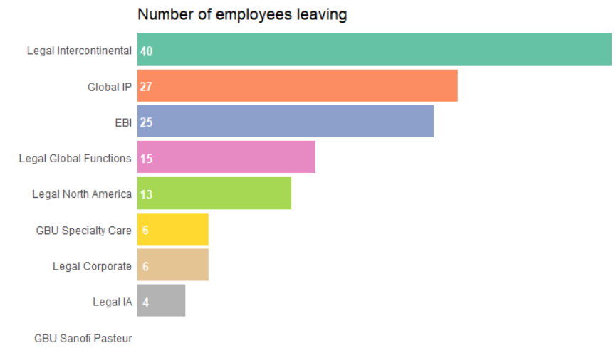

```r
termination$Orga <- fct_infreq(termination$Orga)  # ordre décroissant

ggplot(termination) + aes(x = fct_rev(fct_infreq(Orga)), fill = Orga) + geom_bar(width = 0.9) +
    geom_text(aes(label = ..count..), stat = "count", position = position_fill(0.7),
        colour = "white", fontface = "bold", size = 3.5) + scale_x_discrete(labels = scales::label_wrap(50)) +
    scale_y_continuous(expand = c(0, 0)) + scale_fill_brewer(palette = "Set2") +
    labs(x = "", y = "", fill = "") + ggtitle("Number of employees leaving") + theme_minimal() +
    theme(legend.position = "none", panel.grid = element_blank(), axis.text.x = element_blank()) +
    coord_flip()
```

*Diagramme circulaire*

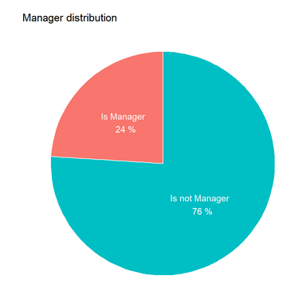

```r
count.data <- data.frame(class = c("Is Manager", "Is not Manager"), n = c(33, 105),
    prop = c(24, 76))

# Add the position of the label
count.data <- count.data %>%
    arrange(desc(class)) %>%
    mutate(lab.ypos = cumsum(prop) - 0.5 * prop)  # add label at the center of the threshold

# Creating pie chart
ggplot(count.data, aes(x = "", y = prop, fill = class)) + geom_bar(width = 1, stat = "identity",
    color = "white") + coord_polar("y", start = 0) + geom_text(aes(y = lab.ypos,
    label = paste(class, "\n", prop, "%")), color = "white") + theme_void() + ggtitle("Manager distribution") +
    theme(legend.position = "none")
```

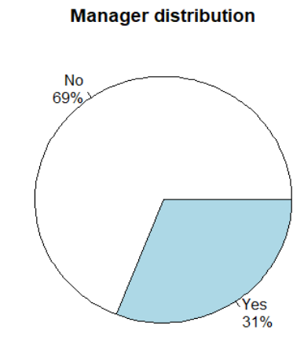

```r
table <- round(prop.table(table(data$Is_Manager)) * 100, 0)
lbls = paste(names(table), "\n", table, "%", sep = "")
pie(table, labels = lbls, main = "Manager distribution")
```

### Analyse bivariée

*Barplot format horizontal %*

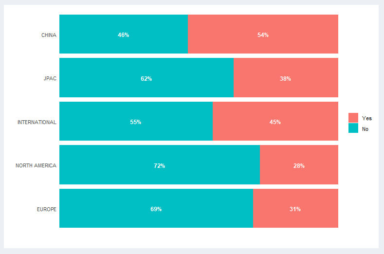

```r
# Fonction pour transformer les étiquettes en %
f <- function(x) {
    res <- scales::percent(x, accuracy = 1)
    res[x < 0.05] <- scales::percent(x[x < 0.05], accuracy = 1, suffix = "")
    res[x < 0.01] <- ""
    res
}

# Avec ggplot
ggplot(donneesCurrent) + aes(x = HFM_Region, fill = Is_Manager, by = factor(HFM_Region),
    label = f(after_stat(prop))) + geom_bar(position = "fill") + geom_text(stat = "prop",
    position = position_fill(0.5), colour = "white", fontface = "bold", size = 3.5) +
    scale_x_discrete(labels = scales::label_wrap(20)) + scale_y_continuous(expand = c(0,
    0)) + labs(x = "", y = "") + theme_minimal() + theme(legend.position = "right",
    legend.title = element_blank(), panel.grid = element_blank(), axis.text.x = element_blank(),
    axis.text.y = element_text()) + coord_flip()
```

```r
library(GGally)
ggbivariate(data = data, outcome = "HFM_Region", explanatory = c("Gender", "Age_Group"),
    title = "HFM Region per Employee Chracteristics", rowbar_args = list(colour = "white",
        size = 3, fontface = "bold", label_format = scales::label_percent(accuracy = 1,
            suffix = "%"))) + scale_fill_brewer(palette = "Set2")
```

*Table*

```r
library(GGally)
ggtable(data = data, columnsX = "HFM_Region", columnsY = c("Gender", "Age_Group"),
    fill = "std.resid", legend = 1) + labs(fill = "Chi²\nResiduals")
```

The color stands for Chi^2 residuals:

- red: under represented => smaller numbers than expected under the assumption of independence
- blue: over represented => bigger numbers than expected under the assumption of independence
- white: close to the expected numbers under the assumption of independence

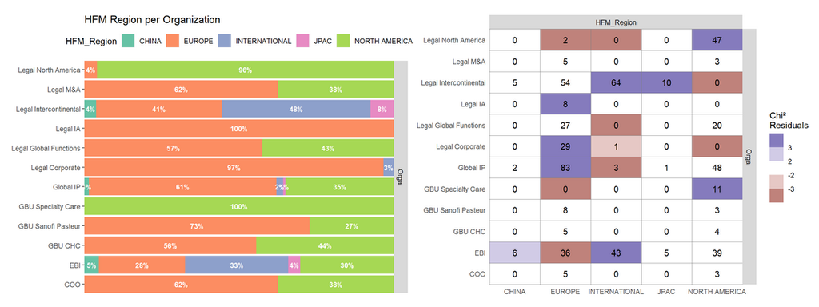

*Barplot format vertical avec facet_wrap + nb*

[figure not shown]

```r
ggplot(termination) + aes(x = fct_infreq(Job_Family_Group), fill = Job_Family_Group) +
    geom_bar() + geom_text(aes(label = ..count..), stat = "count", position = position_dodge(0.5),
    vjust = "top", colour = "white", fontface = "bold", size = 3.5) + facet_wrap(. ~
    Termination_Year) + scale_x_discrete(labels = scales::label_wrap(10)) + scale_y_continuous(expand = c(0,
    0)) + scale_fill_brewer(palette = "Set2") + labs(x = "", y = "", fill = "") +
    ggtitle("per year") + theme_minimal() + theme(legend.position = "none", panel.grid = element_blank(),
    axis.text.x = element_blank())
```

## Variables quantitatives

### Analyse univariée

*Boxplot*

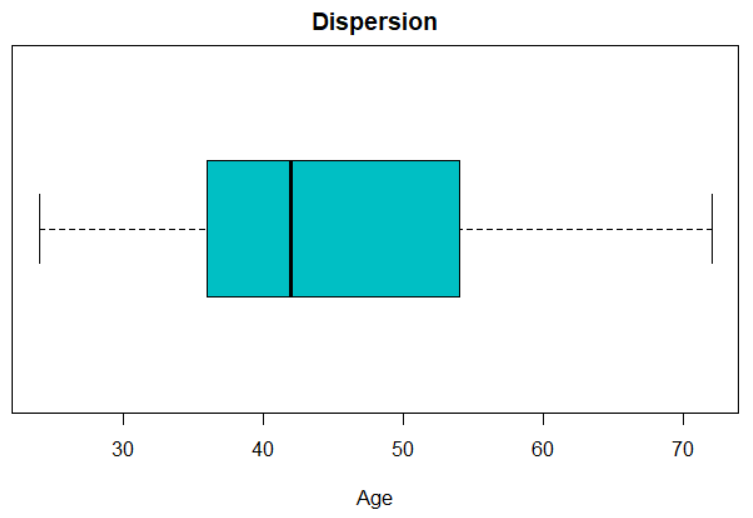

```r
boxplot(termination$Age, horizontal = T, col = "#00BFC4")
title(main = "Dispersion", xlab = "Age")
```

### Analyse bivariée

*Density*

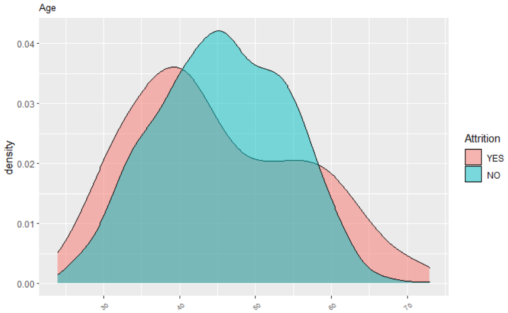

```r
LEBI_HC_ALL %>%
    ggplot(aes(x = Age, fill = Attrition)) + geom_density(alpha = 0.5) + ggtitle("Age") +
    theme(plot.title = element_text(size = 10), axis.text.x = element_text(size = 7,
        angle = 45, hjust = 1), axis.title.x = element_blank())
```

*Boxplot*

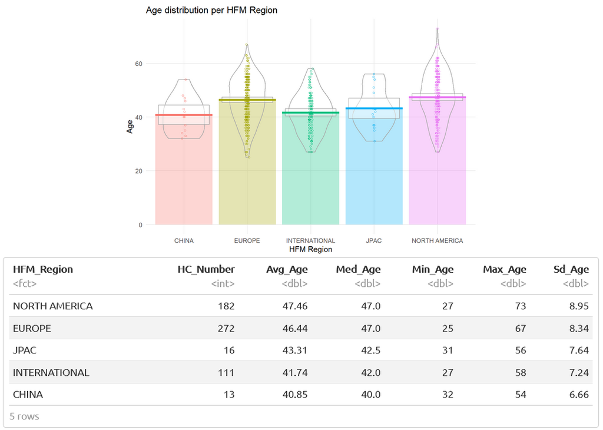

```r
library(ggpirate)
ggplot(data) + aes(x = HFM_Region, y = Age, colour = HFM_Region, fill = HFM_Region) +
    geom_pirate() + xlab("HFM Region") + ylab("Age") + ggtitle("Age distribution per HFM Region") +
    theme_minimal() + theme(panel.grid.minor = element_blank())


paged_table(data %>%
    group_by(HFM_Region) %>%
    summarise(HC_Number = length(Employee_ID), Avg_Age = round(mean(Age), 2), Med_Age = round(median(Age),
        2), Min_Age = round(min(Age), 2), Max_Age = round(max(Age), 2), Sd_Age = round(sd(Age),
        2))) %>%
    arrange(desc(Avg_Age))
```

# Statistiques

## Tests de normalité

The standard deviations (sd) represent less than 50% of the means, which demonstrates low intra-group variations and **confirms the absence of outliers**.

The **means are equal to the medians**, which is an indication of **symmetry**, as are the skew coefficients close to 0.

The negative kurtosis coefficients suggest that the distributions are somewhat compressed, but nevertheless within the normal tolerance interval [-2 ; +2].

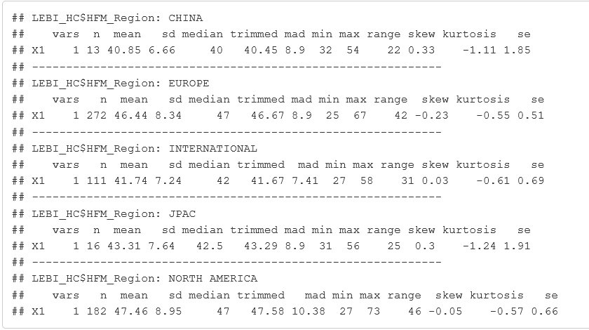

```r
library(psych)
by(LEBI_HC$Age, LEBI_HC$HFM_Region, psych::describe)
```

**Détection des outliers**

Quand la pvaleur > 0.05 => pas outliers

```r
library(outliers)
# boxplot(LEBI_HC$Age ~ LEBI_HC$HFM_Region)
by(LEBI_HC$Age, LEBI_HC$HFM_Region, grubbs.test, opposite = T)
```

**QQplot**

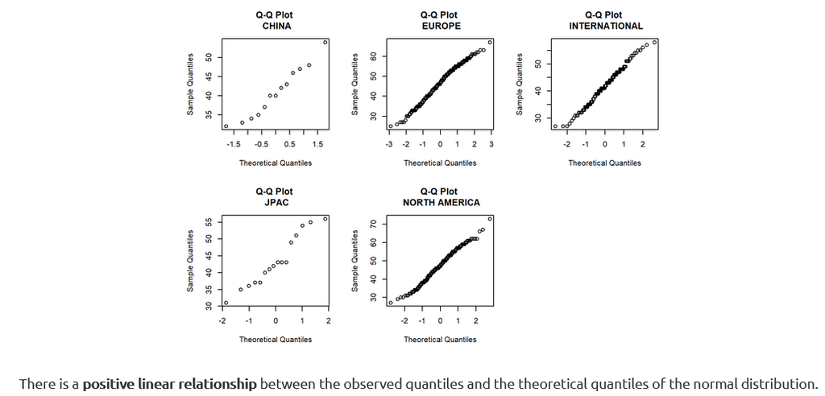

```r
par(mfrow = c(2, 3))
qqnorm(LEBI_HC$Age[LEBI_HC$HFM_Region == "CHINA"], main = "Q-Q Plot \n CHINA")
qqnorm(LEBI_HC$Age[LEBI_HC$HFM_Region == "EUROPE"], main = "Q-Q Plot \n EUROPE")
qqnorm(LEBI_HC$Age[LEBI_HC$HFM_Region == "INTERNATIONAL"], main = "Q-Q Plot \n INTERNATIONAL")
qqnorm(LEBI_HC$Age[LEBI_HC$HFM_Region == "JPAC"], main = "Q-Q Plot \n JPAC")
qqnorm(LEBI_HC$Age[LEBI_HC$HFM_Region == "NORTH AMERICA"], main = "Q-Q Plot \n NORTH AMERICA")
```

**Test de normalité**

Quand la pvaleur > 0.05 => normalité des distributions

```r
by(LEBI_HC$Age, LEBI_HC$HFM_Region, shapiro.test)
```

Pour ne retenir que la pvalue

```r
pSW <- function(x) {
    p <- shapiro.test(x)$p.value
    return(p)
}
apply(iris[, 1:4], 2, pSW)
```